# Hitting Targets

Charl Jooste

March 3, 2020

## How to program for targets

Assume the Minister of Finance asks you how much should the government invest to reach a certain target growth rate over a specified period.

We know from our standard growth models that mainly TFP can generate permanent increases in output. However, it is possible to generate a boost to growth over a short time horizon by investment.

For the analyst to properly answer this question she would have to know how

- Large the fiscal multipliers are
- The sensitivity of inflation is with regards to larger spending
- The leakage of spending due to imports
- The private sector investment crowding out effects of increased government spending
- The initial baseline affects the results

It would seem like a general equilibrium tool is required to answer this question.

**It is important that the baseline include all relevant information**. The simulations will be run on top of the baseline.

## Some programming code

We will start by loading a solved baseline. The relevant EViews code set the global parameters:

```
close @all
logmode l

%fcst_start ="2017"
%fcst_end  = "2030"
%solve_start = "2010"
%cty="SAU"

%path = @runpath
%file = %path+"\output\sausoln_TP.wf1"
wfopen "C:\WBG\LocalITUtilities\KSA\MEP\December2019\Output\SAUSoln.wf1"
```

This is followed by setting the global target and control variables, as well as the target growth rate:

```
%control = "SAUGGEXPFDIFCN" ' SAUGGEXPFDIFCN SAUNECONPRVTKN
%target = "SAUNYGDPNOIL1KN"

scalar GRTARGET = 3  ' Target rate for GDP growth
smpl @first 2019
series {%target}_T = {%target}
smpl 2020 2030
{%target}_T = (1+GRTARGET/100)*{%target}_T(-1)

smpl %fcst_start  %fcst_end
series {%control}_a_hold={%control}_a  ' CREATE A VARIABLE THAT SAVES THE BASELINE ADD-FACTOR
```

If we wish to exclude the responses of certain variables than we may include those variables in the **exos** string:

```
string exos1 = "" ' "SAUBMGSRMRCHCD SAUNEEXPGOILKN"
```

It is possible to multi target and objective variables; we simply group them as:

```
group instruments {%control}_a      ' VARIABLE THAT YOU WANT TO CHANGE IN THE MODEL
group targvars {%target}                ' THIS IS THE VARIABLE THAT MUST CHANGE TO ACHIEVE TARGET
```

Next, we define the scenarios (alias = 1); specify the variables we want to exogenize from the simulation using the **exlude** command, and then calling the **mcontrol** option to run the simulation:

```
{%cty}.scenario(n,a="_1") oc
SAU.exclude {exos1}
{%cty}.mcontrol instruments targvars trajvars
```

## Let’s now examine some of the results

- Let us make sure that the growth objective is reached by plotting baseline GDP (_0) and our simulatin (_1):

```
plot @pc({%target}_0) @pc({%target}_1)
```

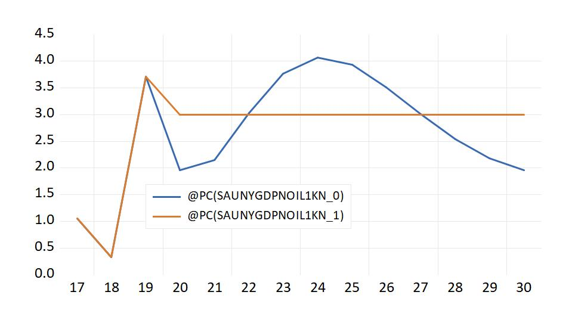

GDP Comparison 1

- Then we plot the economic responses as deviations from baseline
- Note, that the model will throw an error if the baseline is far from steady state (e.g. cannot have very negative numbers or too large of a shock)

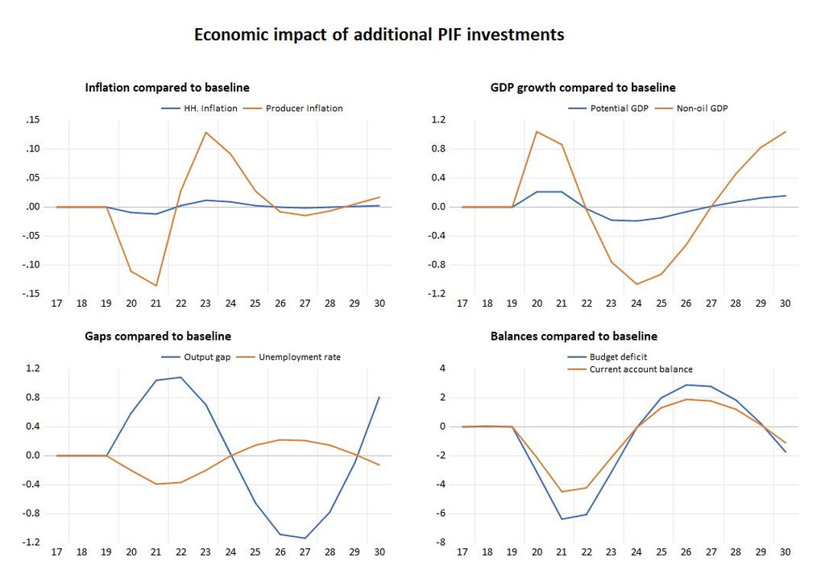

Model responses to simulation

```
group prices1 (@pc(sauneconprvtxn_1)-@pc(sauneconprvtxn_0)) (@pc(saunygdpfcstxn_1)-@pc(saunygdpfcstxn_0))
group output @pc(saunygdppotlkn_1)-@pc(saunygdppotlkn_0) @pc({%target}_1)-@pc({%target}_0)
group budget ((sauggbalovrlcn_1/saunygdpmktpcn_1)-(sauggbalovrlcn_0/saunygdpmktpcn_0))*100 ((saubncabfundcd_1/saunygdpmktpcd_1)-(saubncabfundcd_0/saunygdpmktpcd_0))*100
group gaps (SAUNYGDPGAPNL__1-SAUNYGDPGAPNL__0) (saulfunptotl_1-saulfunptotl_0)

freeze(graphprices,mode=overwrite) prices1.line
graphprices.draw(line, bottom, pattern(dash1)) 2010
graphprices.NAME(1) HH. Inflation
graphprices.NAME(2) Producer Inflation
graphprices.legend position(2.0,-0.34) -inbox
graphprices.addtext(.71,-0.7,font(+b,16)) Inflation compared to baseline

freeze(graphoutput,mode=overwrite) output.line
graphoutput.draw(line, bottom, pattern(dash1)) 2010
graphoutput.NAME(1) Potential GDP
graphoutput.NAME(2) Non-oil GDP
graphoutput.legend position(2.0,-0.34) -inbox
graphoutput.addtext(.71,-0.7,font(+b,16)) GDP growth compared to baseline

freeze(graphgaps,mode=overwrite) gaps.line
graphgaps.draw(line, bottom, pattern(dash1)) 2010
graphgaps.NAME(1) Output gap
graphgaps.NAME(2) Unemployment rate
graphgaps.legend position(2.0,-0.34) -inbox
graphgaps.addtext(.71,-0.7,font(+b,16)) Gaps compared to baseline

freeze(graphbudget,mode=overwrite) budget.line
graphbudget.draw(line, bottom, pattern(dash1)) 2010
graphbudget.NAME(1) Budget deficit
graphbudget.NAME(2) Current account balance
graphbudget.legend position(2.0,-0.34) -inbox
graphbudget.addtext(.71,-0.7,font(+b,16)) Balances compared to baseline

graph comparison2.merge graphprices graphoutput graphgaps graphbudget ' graphprt  'Create graph for key economic variables
comparison2.addtext(0,-2.0,font(+b,24)) Economic impact of additional PIF investments ' and insurance invested in capital over five years
show comparison2
```